# teps_2009_cp

### variable names ###

##### 1. student_id 學生代碼 可以串接往後資料

##### 2. contact 接觸情形 （a:保留有接觸成功 ？）

##### 3. teps_sex 受訪者學生的性別 1:男 2:女 --> 男女受到訪問的人數差不多

[figure not shown]

##### 4. cp09v02是電話接起來的受訪者性別 notice:不一定是本人

##### 5. cp09v05是接起來電話人是學生的 pick up 學生本人？

### education ###

##### 6. cp09v06最高教育程度，包含現在就讀中 （多數2009cp 還是在讀書）有高達2000多位回答現在學歷為大學

[figure not shown]

##### 7. cp09v07受訪者，學生有沒有畢業 針對學生為學生為二專、科大、大學進步詢問。如果是以下者，或是遺漏跳達者，接續到問題12

##### 8. cp09v08受者者的，大學學校分類 1:公立 2:私立 --> 大學、學院 、科大 、技職學院 、 專科 、 國外大學 (值得注意:受者最多為私立大學)

[figure not shown]

##### 9. cp09v08受者major? 以領域分類 --> 以社會科學人數最為多數

[figure not shown]

##### 10. cp09v09受訪者，回答的學校是日間部、夜間部、進修部

##### 11. cp09v10受訪者，這個學制是不是四技、二技或二專？

### education 更詳細的追問特定議題 ###

##### 11. cp09v11受訪者是否以下：轉系、轉學、雙主修、輔系、師資培育、休學、退學

### Job ###

##### 11. cp09v12 現在有沒有全職工作？（請訪員唸出：全職工作的定義是指非學生身份，每星期工作時數達30小時，如果是在念夜間部時做過的全職工作可以算進去） --> 多數人現在都是沒有全職工作

[figure not shown]

##### 11. cp09v13 現在有沒有在找全職工作？

##### 11. cp09v14 之前有沒有做過全職的工作？ 驗證多數人沒有做過全職工作

[figure not shown]

##### 23. cp09v23 這個全職工作平均每個月（稅前）收入大約多少？ 無全職工作跳達

[figure not shown]

```python
from IPython.core.interactiveshell import InteractiveShell
InteractiveShell.ast_node_interactivity = "all"
import matplotlib.pyplot as plt
import matplotlib.font_manager as fm
import seaborn as sns
import numpy as np
import pandas as pd
plt.style.use('ggplot')

plt.rcParams['font.family'] = ['Arial Unicode MS']
font_path = '/System/Library/Fonts/PingFang.ttc'
font_prop = fm.FontProperties(fname=font_path, size=16)


df=pd.read_csv('2009CP-1.csv',encoding='utf-8')
df.head()
```

|  | stud_id | contact | tepsb_sex | cp09v02 | cp09v05 | cp09v06 | cp09v07 | cp09v08_u | cp09v08_ud | cp09v09 | ... | cp09v19 | cp09v20 | cp09v20_k | cp09v21 | cp09v22 | cp09v23 | cp09v24 | cp09v25 | cp09v26 | cp09v27 |
| --- | --- | --- | --- | --- | --- | --- | --- | --- | --- | --- | --- | --- | --- | --- | --- | --- | --- | --- | --- | --- | --- |
| 0 | 16183 | 正式成功完訪 | 男 | 男 | 學生本人 | 技術學院或科技大學 | 沒有，還沒畢業（指還在唸書） | 公立科技大學 | 工程、製造及營造領域 | 日間部 | ... | 跳答 | 跳答 | 跳答 | 跳答 | 跳答 | 跳答 | 跳答 | 跳答 | 178 | 72 |
| 1 | 5433 | 正式成功完訪 | 女 | 女 | 學生本人 | 技術學院或科技大學 | 沒有，還沒畢業（指還在唸書） | 公立科技大學 | 社會科學、商業及法律領域 | 日間部 | ... | 跳答 | 跳答 | 跳答 | 跳答 | 跳答 | 跳答 | 跳答 | 跳答 | 160 | 49 |
| 2 | 16661 | 正式成功完訪 | 女 | 女 | 媽媽（含繼母、養母） | 大學 | 沒有，還沒畢業（指還在唸書） | 私立一般大學 | 社會科學、商業及法律領域 | 日間部 | ... | 跳答 | 跳答 | 跳答 | 跳答 | 跳答 | 跳答 | 跳答 | 跳答 | 166 | 不清楚、不知道 |
| 3 | 12413 | 正式成功完訪 | 男 | 男 | 學生本人 | 技術學院或科技大學 | 沒有，還沒畢業（指還在唸書） | 私立科技大學 | 科學領域 | 日間部 | ... | 跳答 | 跳答 | 跳答 | 跳答 | 跳答 | 跳答 | 跳答 | 跳答 | 172 | 57 |
| 4 | 16380 | 正式成功接觸未完訪 | 女 | 遺漏值 | 遺漏值 | 遺漏值 | 遺漏值 | 遺漏值 | 遺漏值 | 遺漏值 | ... | 遺漏值 | 遺漏值 | 跳答 | 遺漏值 | 遺漏值 | 遺漏值 | 遺漏值 | 遺漏值 | 遺漏值 | 遺漏值 |

5 rows × 38 columns

```python
df.columns
```

```python
import pandas as pd

# Create an empty DataFrame to store the results
results_df = pd.DataFrame()

# Loop through each column in the DataFrame
for col in df.columns:
    # Check if the column contains numerical data
    #if df[col].dtype != 'object':
        # Calculate the descriptive statistics for the column
        stats = df[col].describe()
        # Add the column name as a new row index
        stats.name = col
        # Transpose the result and add it to the results DataFrame
        results_df = pd.concat([results_df, stats.to_frame().T])

# Print the results DataFrame
print(results_df)
```

```
             count          mean          std  min     25%      50%      75%  \
stud_id     4261.0  10019.149261  5814.838232  2.0  5011.0  10029.0  15090.0
contact       4261           NaN          NaN  NaN     NaN      NaN      NaN
tepsb_sex     4261           NaN          NaN  NaN     NaN      NaN      NaN
cp09v02       4261           NaN          NaN  NaN     NaN      NaN      NaN
cp09v05       4261           NaN          NaN  NaN     NaN      NaN      NaN
cp09v06       4261           NaN          NaN  NaN     NaN      NaN      NaN
cp09v07       4261           NaN          NaN  NaN     NaN      NaN      NaN
cp09v08_u     4261           NaN          NaN  NaN     NaN      NaN      NaN
cp09v08_ud    4261           NaN          NaN  NaN     NaN      NaN      NaN
cp09v09       4261           NaN          NaN  NaN     NaN      NaN      NaN
cp09v10       4261           NaN          NaN  NaN     NaN      NaN      NaN
cp09v11_1     4261           NaN          NaN  NaN     NaN      NaN      NaN
cp09v11_2     4261           NaN          NaN  NaN     NaN      NaN      NaN
cp09v11_3     4261           NaN          NaN  NaN     NaN      NaN      NaN
cp09v11_4     4261           NaN          NaN  NaN     NaN      NaN      NaN
cp09v11_5     4261           NaN          NaN  NaN     NaN      NaN      NaN
cp09v11_6     4261           NaN          NaN  NaN     NaN      NaN      NaN
cp09v11_7     4261           NaN          NaN  NaN     NaN      NaN      NaN
cp09v11_8     4261           NaN          NaN  NaN     NaN      NaN      NaN
cp09v11_9     4261           NaN          NaN  NaN     NaN      NaN      NaN
cp09v11_10    4261           NaN          NaN  NaN     NaN      NaN      NaN
cp09v12       4261           NaN          NaN  NaN     NaN      NaN      NaN
cp09v13       4261           NaN          NaN  NaN     NaN      NaN      NaN
cp09v14       4261           NaN          NaN  NaN     NaN      NaN      NaN
cp09v15       4261           NaN          NaN  NaN     NaN      NaN      NaN
cp09v16       4261           NaN          NaN  NaN     NaN      NaN      NaN
cp09v17       4261           NaN          NaN  NaN     NaN      NaN      NaN
cp09v18       4261           NaN          NaN  NaN     NaN      NaN      NaN
cp09v19       4261           NaN          NaN  NaN     NaN      NaN      NaN
cp09v20       4261           NaN          NaN  NaN     NaN      NaN      NaN
cp09v20_k     4261           NaN          NaN  NaN     NaN      NaN      NaN
cp09v21       4261           NaN          NaN  NaN     NaN      NaN      NaN
cp09v22       4261           NaN          NaN  NaN     NaN      NaN      NaN
cp09v23       4261           NaN          NaN  NaN     NaN      NaN      NaN
cp09v24       4261           NaN          NaN  NaN     NaN      NaN      NaN
cp09v25       4261           NaN          NaN  NaN     NaN      NaN      NaN
cp09v26       4261           NaN          NaN  NaN     NaN      NaN      NaN
cp09v27       4261           NaN          NaN  NaN     NaN      NaN      NaN

```

[output cut: 24 more lines]

```
cp09v14         NaN      5             沒有（跳答第26題）  2821
cp09v15         NaN      7                     跳答  2835
cp09v16         NaN      5                     跳答  2869
cp09v17         NaN     13                     跳答  2835
cp09v18         NaN     55                     跳答  2835
cp09v19         NaN     22                     跳答  2836
cp09v20         NaN      5                     跳答  2835
cp09v20_k       NaN     18                     跳答  4218
cp09v21         NaN      9                     跳答  2835
cp09v22         NaN     51                     跳答  2837
cp09v23         NaN     15                     跳答  2835
cp09v24         NaN      4                     跳答  2835
cp09v25         NaN      9                     跳答  3083
cp09v26         NaN     55                    遺漏值  1078
cp09v27         NaN     79                    遺漏值  1081
```

```python
for col in df.columns:
    #if df[col].dtype != 'object': # check if the column contains numerical data
        print(col)
        print(df[col].describe())
        print('-' * 50) # add a separator line
```

```
stud_id
count     4261.000000
mean     10019.149261
std       5814.838232
min          2.000000
25%       5011.000000
50%      10029.000000
75%      15090.000000
max      20052.000000
Name: stud_id, dtype: float64
--------------------------------------------------
contact
count       4261
unique         6
top       正式成功完訪
freq        3184
Name: contact, dtype: object
--------------------------------------------------
tepsb_sex
count     4261
unique       2
top          女
freq      2148
Name: tepsb_sex, dtype: object
--------------------------------------------------
cp09v02
count     4261
unique       3
top          女
freq      1695
Name: cp09v02, dtype: object
--------------------------------------------------
cp09v05
count     4261
unique       8
top       學生本人
freq      2848
Name: cp09v05, dtype: object
--------------------------------------------------
cp09v06
```

[output cut: 215 more lines]

```
--------------------------------------------------
cp09v26
count     4261
unique      55
top        遺漏值
freq      1078
Name: cp09v26, dtype: object
--------------------------------------------------
cp09v27
count     4261
unique      79
top        遺漏值
freq      1081
Name: cp09v27, dtype: object
--------------------------------------------------
```

```python
import matplotlib.pyplot as plt
plt.style.use('ggplot')
for col in df.columns:
    if df[col].dtype == 'object': # check if the column contains categorical data
        ax = df[col].value_counts().plot(kind='barh', figsize=(12, 9), rot=20, fontsize=12, colormap='plasma')
        for i in ax.containers:
            ax.bar_label(i, label_type='edge')
        plt.xticks(rotation=20)
        plt.title(col, fontsize=16) # set the title of the plot to the column name
        plt.tight_layout()
        plt.savefig(col+'.png',dpi=10000, )
        plt.show()
```

```
[Text(0, 0, '3184'),
```

```
(array([   0.,  500., 1000., 1500., 2000., 2500., 3000., 3500.]),
 [Text(0.0, 0, '0'),
```

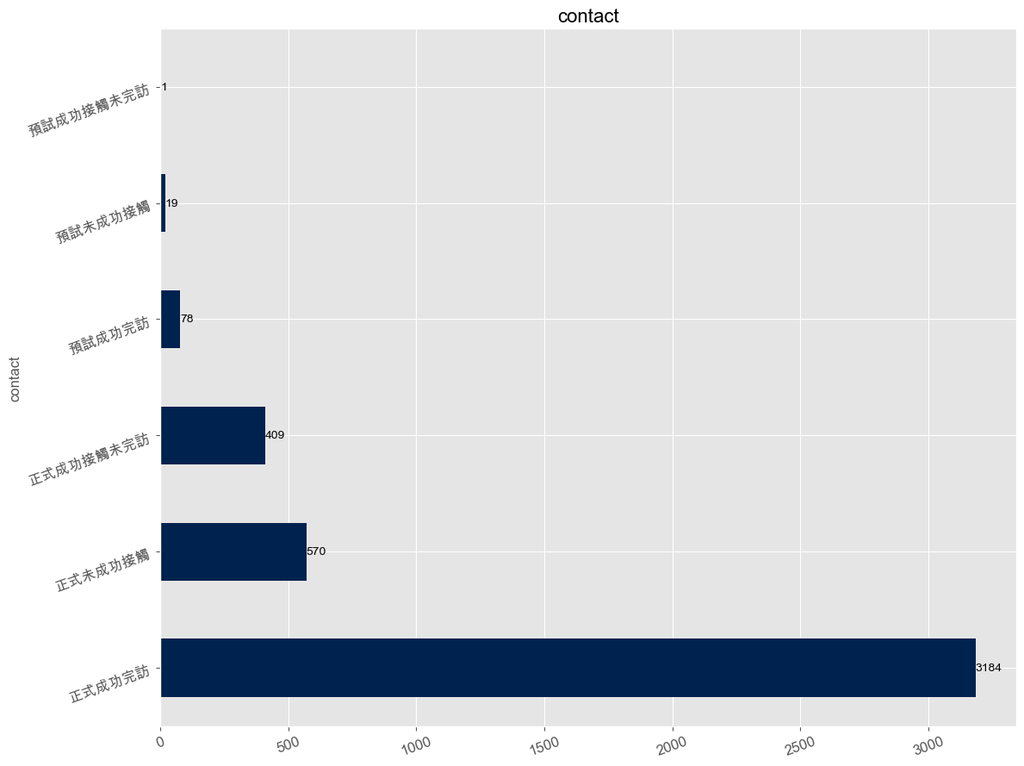

```
[Text(0, 0, '2148'), Text(0, 0, '2113')]
```

```
(array([   0.,  500., 1000., 1500., 2000., 2500.]),
 [Text(0.0, 0, '0'),
```

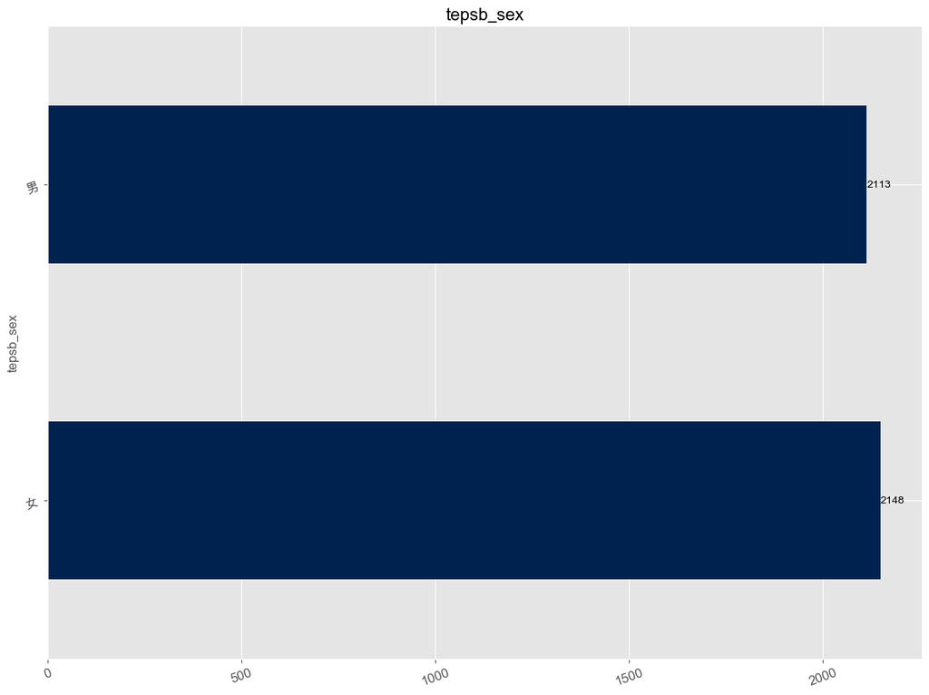

```
[Text(0, 0, '1695'), Text(0, 0, '1539'), Text(0, 0, '1027')]
```

```
(array([   0.,  200.,  400.,  600.,  800., 1000., 1200., 1400., 1600.,
        1800.]),
 [Text(0.0, 0, '0'),
```

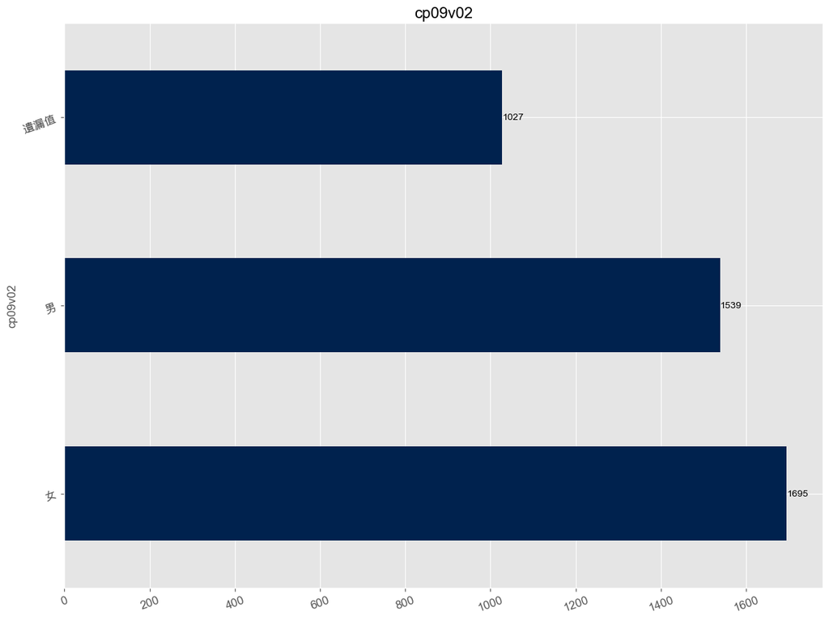

```
[Text(0, 0, '2848'),
```

```
(array([   0.,  500., 1000., 1500., 2000., 2500., 3000.]),
 [Text(0.0, 0, '0'),
```

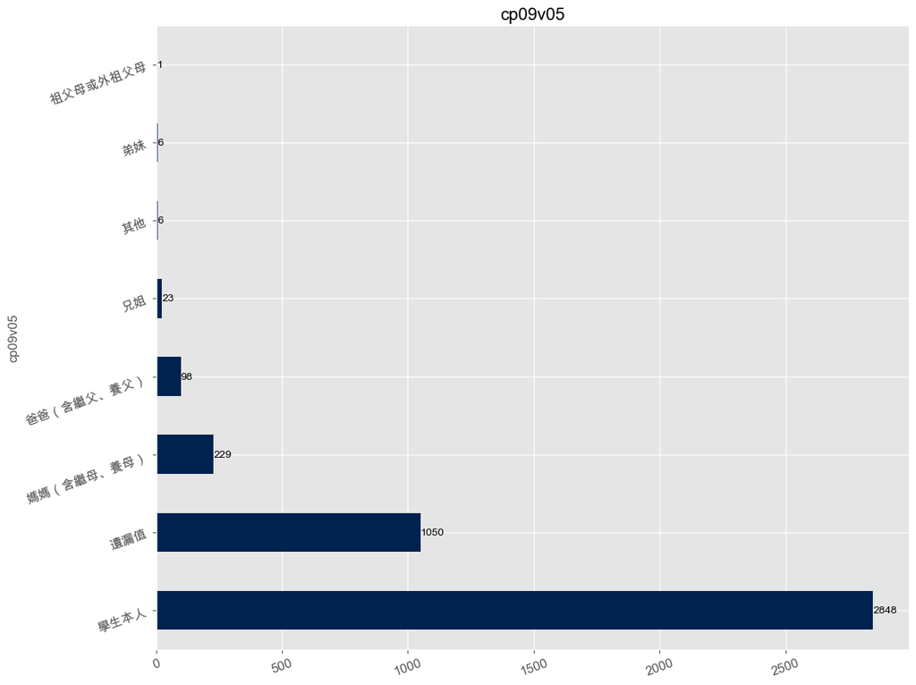

```
[Text(0, 0, '2011'),
```

```
(array([   0.,  250.,  500.,  750., 1000., 1250., 1500., 1750., 2000.,
        2250.]),
 [Text(0.0, 0, '0'),
```

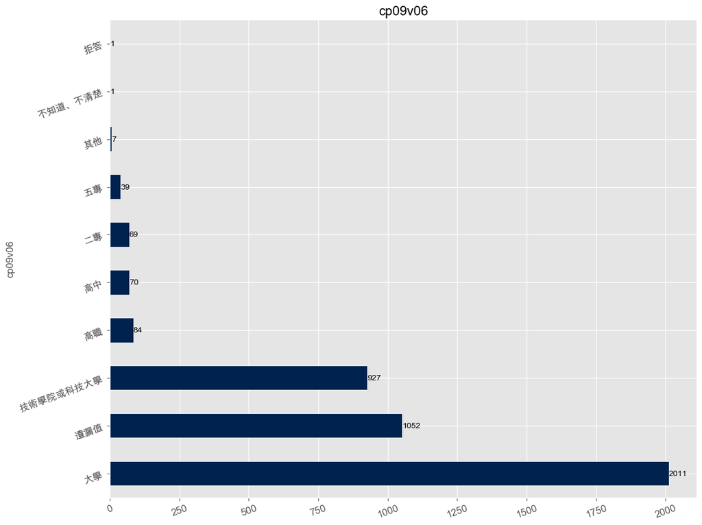

```
[Text(0, 0, '2940'), Text(0, 0, '1053'), Text(0, 0, '195'), Text(0, 0, '73')]
```

```
(array([   0.,  500., 1000., 1500., 2000., 2500., 3000., 3500.]),
 [Text(0.0, 0, '0'),
```

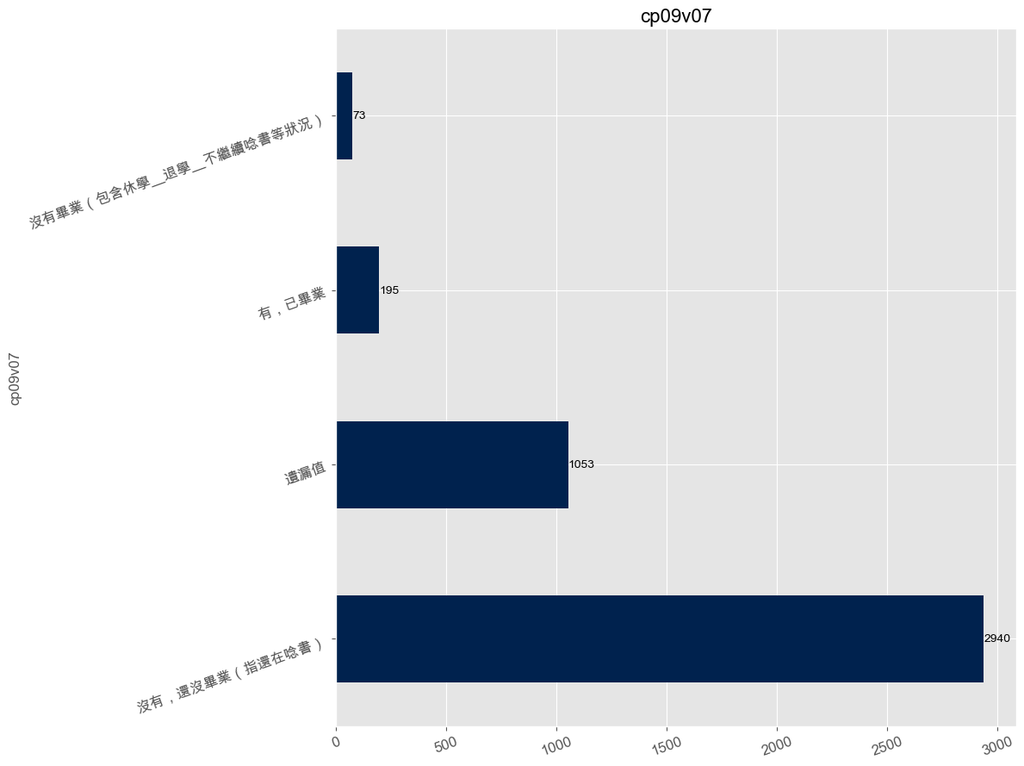

```
[Text(0, 0, '1167'),
```

```
(array([   0.,  200.,  400.,  600.,  800., 1000., 1200., 1400.]),
 [Text(0.0, 0, '0'),
```

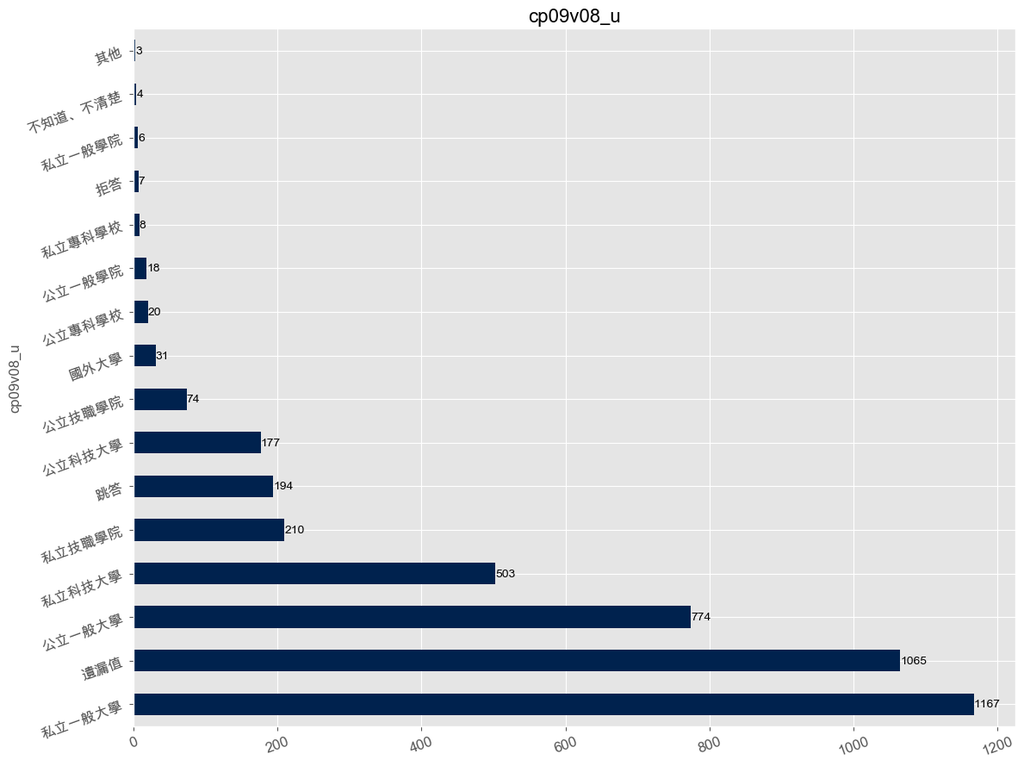

```
[Text(0, 0, '1065'),
```

```
(array([   0.,  200.,  400.,  600.,  800., 1000., 1200.]),
 [Text(0.0, 0, '0'),
```

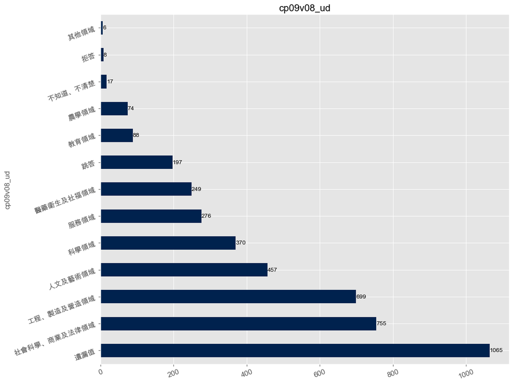

```
[Text(0, 0, '2777'),
```

```
(array([   0.,  500., 1000., 1500., 2000., 2500., 3000.]),
 [Text(0.0, 0, '0'),
```

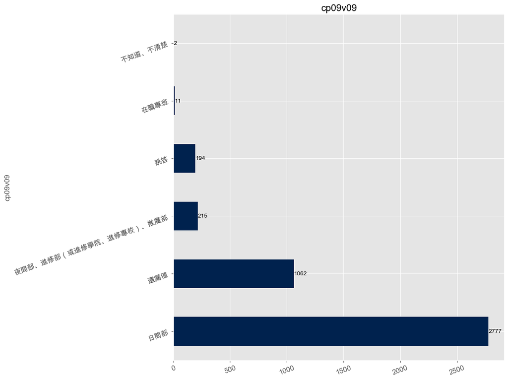

```
[Text(0, 0, '1947'),
```

```
(array([   0.,  250.,  500.,  750., 1000., 1250., 1500., 1750., 2000.,
        2250.]),
 [Text(0.0, 0, '0'),
```

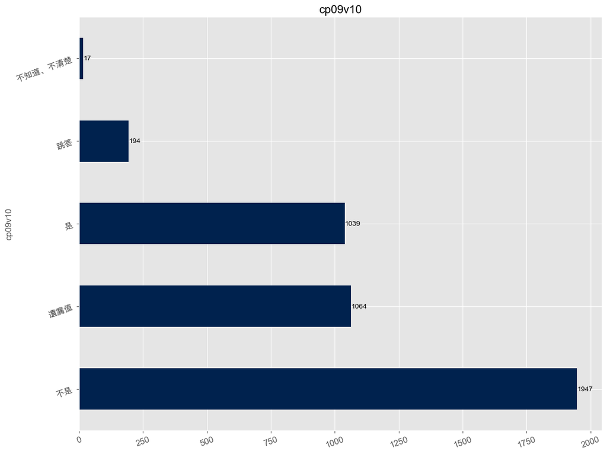

```
[Text(0, 0, '2820'), Text(0, 0, '1069'), Text(0, 0, '194'), Text(0, 0, '178')]
```

```
(array([   0.,  500., 1000., 1500., 2000., 2500., 3000.]),
 [Text(0.0, 0, '0'),
```

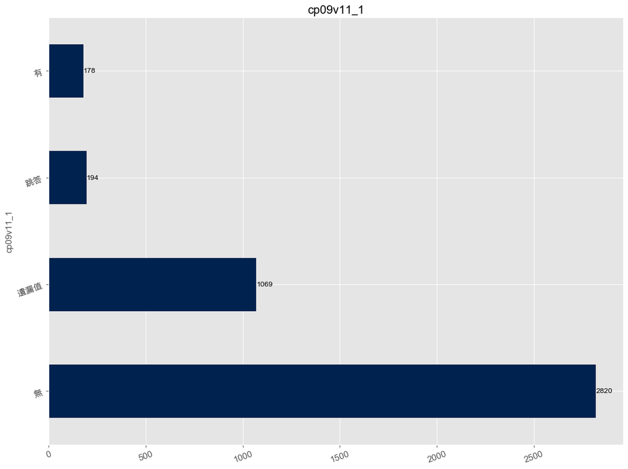

```
[Text(0, 0, '2902'), Text(0, 0, '1069'), Text(0, 0, '194'), Text(0, 0, '96')]
```

```
(array([   0.,  500., 1000., 1500., 2000., 2500., 3000., 3500.]),
 [Text(0.0, 0, '0'),
```

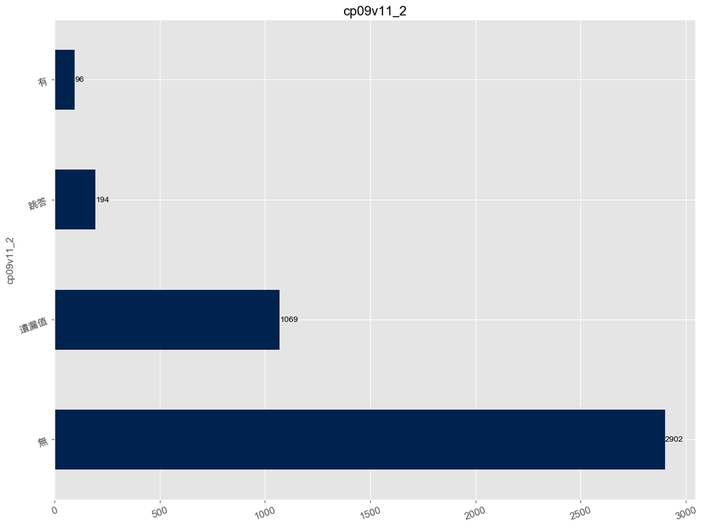

```
[Text(0, 0, '2939'), Text(0, 0, '1069'), Text(0, 0, '194'), Text(0, 0, '59')]
```

```
(array([   0.,  500., 1000., 1500., 2000., 2500., 3000., 3500.]),
 [Text(0.0, 0, '0'),
```

[25 more figures not shown]

```python
import os
import matplotlib.pyplot as plt

save_dir = '/Users/heng/Documents/master_eco_thesis/graph/'

for col in df.columns:
    if df[col].dtype == 'object': # check if the column contains categorical data
        ax = df[col].value_counts().plot(kind='barh', figsize=(12, 9), rot=20, fontsize=12, colormap='cividis')
        for i in ax.containers:
            ax.bar_label(i, label_type='edge')
        plt.xticks(rotation=20)
        plt.title(col, fontsize=16) # set the title of the plot to the column name
        plt.tight_layout()
        #plt.savefig(os.path.join(save_dir, col+'.png'))
        plt.show()
```